# Introduction to the Tidyverse: An Exploration of UN Data

In this project, you’ll be redoing the UN Data project using the tidyverse libraries. You have been provided three csv files, gdp_per_capita.csv, life_expectancy.csv, and continents.csv.

```r
library(tidyverse)
```

1. Using the `read_csv()` function, read the GDP dataset into your notebook as a tibble called `gdp_df`. After reading it in, inspect the first 10 rows and then inspect the last 10 rows.

```r
gdp_df <- read_csv("../data/gdp_per_capita.csv", show_col_types = FALSE)
gdp_df |>
  head(10)
```

| Country or Area | Year | Value | Value Footnotes |
| --- | --- | --- | --- |
| Afghanistan | 2021 | 1517.016 | NA |
| Afghanistan | 2020 | 1968.341 | NA |
| Afghanistan | 2019 | 2079.922 | NA |
| Afghanistan | 2018 | 2060.699 | NA |
| Afghanistan | 2017 | 2096.093 | NA |
| Afghanistan | 2016 | 2101.422 | NA |
| Afghanistan | 2015 | 2108.714 | NA |
| Afghanistan | 2014 | 2144.450 | NA |
| Afghanistan | 2013 | 2165.341 | NA |
| Afghanistan | 2012 | 2122.831 | NA |

```r
gdp_df |>
  tail(10)
```

| Country or Area | Year | Value | Value Footnotes |
| --- | --- | --- | --- |
| Zimbabwe | 1999 | 2866.033 | NA |
| Zimbabwe | 1998 | 2931.725 | NA |
| Zimbabwe | 1997 | 2896.147 | NA |
| Zimbabwe | 1996 | 2867.026 | NA |
| Zimbabwe | 1995 | 2641.378 | NA |
| Zimbabwe | 1994 | 2670.107 | NA |
| Zimbabwe | 1993 | 2458.783 | NA |
| Zimbabwe | 1992 | 2468.278 | NA |
| Zimbabwe | 1991 | 2781.788 | NA |
| Zimbabwe | 1990 | 2704.757 | NA |

2. Drop the ‘Value Footnotes’ column, and rename the remaining columns to ‘Country’, ‘Year’, and ‘GDP_Per_Capita’.

```r
gdp_df <- gdp_df |>
  select(
    Country = 'Country or Area',
    Year,
    GDP_Per_Capita = Value)
```

3. Which years are represented in this dataset? How many observations are there per year? Make a plot to view the number of observations per year.

```r
# find number of unique years
years_distinct <- gdp_df |>
  distinct(Year)
print(count(years_distinct))
```

| n |
| --- |
| 33 |

```r
print(range(years_distinct))
```

```
[1] 1990 2022
```

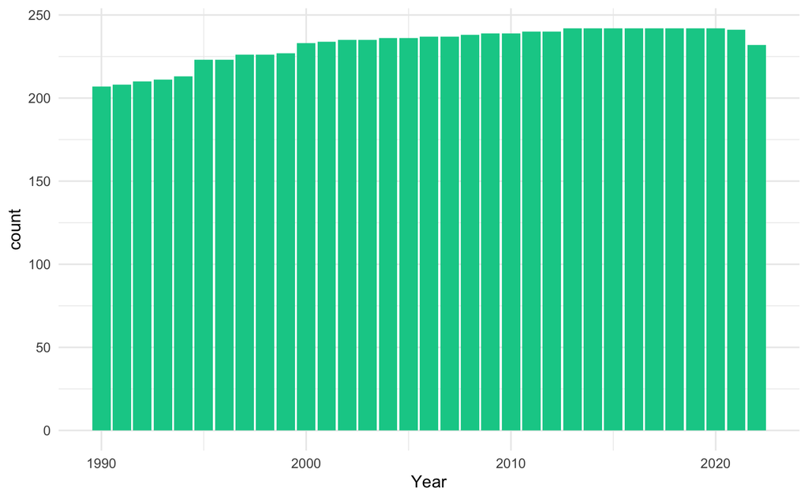

```r
# create barplot for number of countries per year
ggplot(gdp_df, aes(x=Year)) +
  geom_bar(fill='#00CC96') +
  theme_minimal()
```

4. How many countries are represented in this dataset? Which countries have the fewest observations?

```r
# how many countries?
countries_distinct <- gdp_df |>
  distinct(Country)
print(count(countries_distinct))
```

| n |
| --- |
| 242 |

```r
# fewest observations
gdp_df |>
  count(Country, sort=TRUE) |>
  tail()
```

| Country | n |
| --- | --- |
| Cayman Islands | 16 |
| Kosovo | 15 |
| Sint Maarten (Dutch part) | 14 |
| Turks and Caicos Islands | 12 |
| Djibouti | 10 |
| Somalia | 10 |

5. Create a new tibble by subsetting `gdp_df` to just the year 2021. Call this new tibble `gdp_2021`.

```r
# filter to year 2021
gdp_2021 <- gdp_df |>
  filter(Year==2021)
```

6. Use `summary()` to find the summary statistics for GDP per capita in 2021.

```r
gdp_2021 |>
  summary()
```

```
   Country               Year      GDP_Per_Capita
 Length:241         Min.   :2021   Min.   :   714.1
 Class :character   1st Qu.:2021   1st Qu.:  5044.2
 Mode  :character   Median :2021   Median : 13754.8
                    Mean   :2021   Mean   : 20711.6
                    3rd Qu.:2021   3rd Qu.: 30974.4
                    Max.   :2021   Max.   :115683.5
```

7. Create a histogram of GDP Per Capita numbers for 2021 (you may wish to adjust the number of bins for your histogram).

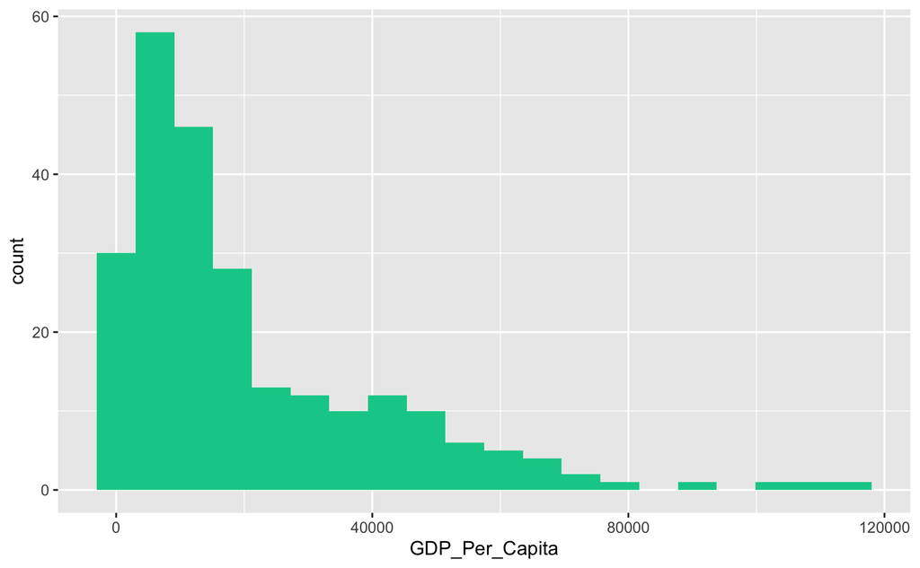

```r
ggplot(gdp_2021, aes(x=GDP_Per_Capita)) +
  geom_histogram(bins=20, fill='#00CC96')
```

8. Find the top 5 counties and bottom 5 countries by GDP per capita in 2021.

```r
# top five
top_five_gdppc <- gdp_2021 |>
  arrange(desc(GDP_Per_Capita)) |>
  head()
# bottom five
bottom_five_gdppc <-gdp_2021 |>
  arrange(desc(GDP_Per_Capita)) |>
  tail()
```

[output not shown]

9. Now, return to the full dataset, `gdp_df`. Pivot the data for 1990 and 2021 (using `pivot_wider()` function) so that each row corresponds to a country, each column corresponds to a year, and the values in the table give the GDP_Per_Capita amount. Drop any rows that are missing values for either 1990 or 2021. Save the result to a tibble named `gdp_pivoted`.

```r
# pivot data to wide format, drop NA values in 1990 | 2021
gdp_pivoted <- gdp_df |>
  pivot_wider(values_from = GDP_Per_Capita, names_from = Year) |>
  drop_na(c('1990', '2021'))

gdp_pivoted
```

| Country | 2021 | 2020 | 2019 | 2018 | 2017 | 2016 | 2015 | 2014 | 2013 | 2012 | 2011 | 2010 | 2009 | 2008 | 2007 | 2006 | 2005 | 2004 | 2003 | 2002 | 2022 | 2001 | 2000 | 1999 | 1998 | 1997 | 1996 | 1995 | 1994 | … |
| --- | --- | --- | --- | --- | --- | --- | --- | --- | --- | --- | --- | --- | --- | --- | --- | --- | --- | --- | --- | --- | --- | --- | --- | --- | --- | --- | --- | --- | --- | --- |
| Africa Eastern and Southern | 3519.1748 | 3455.0231 | 3648.2203 | 3661.3606 | 3659.0591 | 3654.5788 | 3658.5336 | 3642.8754 | 3593.2991 | 3543.8249 | 3558.3785 | 3513.3159 | 3431.1780 | 3501.8381 | 3440.8412 | 3310.5150 | 3185.3941 | 3075.5462 | 2985.9186 | 2966.0398 | 3553.9134 | 2928.0629 | 2897.1408 | 2873.5537 | 2867.9602 | 2886.5662 | 2838.6920 | 2764.3050 | 2715.1311 | … |
| Africa Western and Central | 4014.6080 | 3957.9338 | 4093.4429 | 4064.0799 | 4051.2712 | 4055.9433 | 4148.5473 | 4146.9946 | 4026.2319 | 3901.7248 | 3811.7604 | 3737.5067 | 3599.3515 | 3491.5474 | 3379.5521 | 3296.9528 | 3217.7024 | 3128.2967 | 2982.7083 | 2907.9834 | 4063.8577 | 2734.2576 | 2671.5992 | 2649.5559 | 2676.5298 | 2654.3849 | 2612.1948 | 2561.6654 | 2575.0642 | … |
| Albania | 14595.9444 | 13278.3698 | 13653.1822 | 13317.1193 | 12770.9919 | 12291.8421 | 11878.4376 | 11586.8174 | 11361.2525 | 11227.9504 | 11052.7779 | 10749.4664 | 10313.9017 | 9912.1485 | 9150.1168 | 8568.5497 | 8040.0814 | 7580.1281 | 7153.9954 | 6753.8812 | 15501.6629 | 6441.4407 | 5892.5822 | 5474.8499 | 4819.0678 | 4400.3128 | 4908.9324 | 4471.6017 | 3921.6150 | … |
| Algeria | 11029.1388 | 10844.7708 | 11627.2799 | 11725.8777 | 11809.4830 | 11888.3230 | 11751.6341 | 11561.2598 | 11360.6376 | 11270.7010 | 11113.9689 | 11007.7466 | 10824.5764 | 10847.1766 | 10775.5321 | 10592.2471 | 10566.3728 | 10114.7256 | 9835.1617 | 9299.6821 | 11187.3823 | 8926.1101 | 8786.1903 | 8584.0715 | 8435.0357 | 8147.8782 | 8195.8605 | 8013.1234 | 7869.2703 | … |
| Angola | 5911.8357 | 6029.6919 | 6602.2692 | 6878.5900 | 7216.0614 | 7487.9251 | 7966.8856 | 8183.1646 | 8099.6788 | 8011.0501 | 7663.2861 | 7689.8207 | 7646.1444 | 7866.1843 | 7340.3889 | 6677.0197 | 6204.5888 | 5589.2379 | 5217.3905 | 5241.8206 | 5906.1157 | 4768.0089 | 4728.3744 | 4739.5096 | 4790.4186 | 4728.2923 | 4557.1478 | 4149.4457 | 3728.8862 | … |
| Antigua and Barbuda | 19899.8824 | 18787.5644 | 22908.6393 | 22072.5557 | 20777.5595 | 20267.5488 | 19344.6656 | 18779.1391 | 18243.4826 | 18526.0537 | 18116.8565 | 18701.7502 | 20571.5327 | 23726.9483 | 24087.6839 | 22340.3857 | 20076.0738 | 19077.0635 | 18236.9351 | 17388.2275 | 21457.9379 | 17432.7007 | 18545.5826 | 17754.2217 | 17414.1312 | 16943.5872 | 16391.4203 | 15690.6447 | 16730.2139 | … |
| Arab World | 13745.2062 | 13466.4898 | 14358.1691 | 14420.0122 | 14332.3535 | 14388.8593 | 14148.5282 | 13872.2273 | 13836.2235 | 13788.1720 | 13329.3847 | 13162.0296 | 12892.3313 | 13164.4449 | 12806.2082 | 12577.7850 | 12190.3986 | 11830.8722 | 11148.0202 | 10857.6120 | 14324.3966 | 11031.1691 | 11082.7423 | 10654.9442 | 10685.0582 | 10393.1723 | 10193.8458 | 9975.5305 | 9954.2245 | … |
| Argentina | 21527.1961 | 19685.2159 | 22071.7481 | 22747.2417 | 23597.1178 | 23189.5274 | 23933.8866 | 23550.0991 | 24424.1364 | 24118.8675 | 24647.6293 | 23521.2702 | 21413.2831 | 22992.3902 | 22316.2555 | 20679.2431 | 19338.1462 | 17950.1513 | 16631.5740 | 15439.7446 | 22447.0885 | 17514.5041 | 18524.8096 | 18884.9431 | 19773.1764 | 19261.8986 | 18031.5482 | 17303.9238 | 18046.8929 | … |
| Armenia | 14193.1168 | 13357.6971 | 14317.5529 | 13231.4311 | 12509.6396 | 11580.3836 | 11506.0390 | 11105.5325 | 10677.3037 | 10289.9756 | 9551.1581 | 9068.7877 | 8819.6775 | 10201.5595 | 9476.4715 | 8273.7857 | 7259.2039 | 6334.8562 | 5698.7785 | 4965.2244 | 16041.8297 | 4346.9075 | 3921.8575 | 3660.0341 | 3505.3684 | 3236.0605 | 3105.9528 | 2912.7811 | 2683.6375 | … |
| Aruba | 38866.3335 | 33155.2432 | 40780.5165 | 40706.7492 | 38865.1882 | 37043.6982 | 36490.5245 | 35467.2358 | 35720.6981 | 33815.1093 | 34446.8569 | 33639.3962 | 34978.0091 | 40096.7815 | 39866.7156 | 39146.9093 | 39166.1338 | 39713.8467 | 37353.5587 | 37309.7879 | NA | 38123.3424 | 37241.0305 | 35495.2486 | 36105.2602 | 36479.9418 | 35125.9271 | 35780.7228 | 35984.8294 | … |

[output cut: 196 more lines]

10. Create a new column in `gdp_pivoted` named `Percent_Change`. This column should contain the percent change in GDP_Per_Capita from 1990 to 2021. Hint: Percent change is calculated as 100*(New Value - Old Value) / Old Value.

```r
gdp_pivoted <- gdp_pivoted |>
  mutate('Percent_Change' = 100*(`2021`-`1990`)/`1990`)

gdp_pivoted
```

| Country | 2021 | 2020 | 2019 | 2018 | 2017 | 2016 | 2015 | 2014 | 2013 | 2012 | 2011 | 2010 | 2009 | 2008 | 2007 | 2006 | 2005 | 2004 | 2003 | 2002 | 2022 | 2001 | 2000 | 1999 | 1998 | 1997 | 1996 | 1995 | 1994 | … |
| --- | --- | --- | --- | --- | --- | --- | --- | --- | --- | --- | --- | --- | --- | --- | --- | --- | --- | --- | --- | --- | --- | --- | --- | --- | --- | --- | --- | --- | --- | --- |
| Africa Eastern and Southern | 3519.1748 | 3455.0231 | 3648.2203 | 3661.3606 | 3659.0591 | 3654.5788 | 3658.5336 | 3642.8754 | 3593.2991 | 3543.8249 | 3558.3785 | 3513.3159 | 3431.1780 | 3501.8381 | 3440.8412 | 3310.5150 | 3185.3941 | 3075.5462 | 2985.9186 | 2966.0398 | 3553.9134 | 2928.0629 | 2897.1408 | 2873.5537 | 2867.9602 | 2886.5662 | 2838.6920 | 2764.3050 | 2715.1311 | … |
| Africa Western and Central | 4014.6080 | 3957.9338 | 4093.4429 | 4064.0799 | 4051.2712 | 4055.9433 | 4148.5473 | 4146.9946 | 4026.2319 | 3901.7248 | 3811.7604 | 3737.5067 | 3599.3515 | 3491.5474 | 3379.5521 | 3296.9528 | 3217.7024 | 3128.2967 | 2982.7083 | 2907.9834 | 4063.8577 | 2734.2576 | 2671.5992 | 2649.5559 | 2676.5298 | 2654.3849 | 2612.1948 | 2561.6654 | 2575.0642 | … |
| Albania | 14595.9444 | 13278.3698 | 13653.1822 | 13317.1193 | 12770.9919 | 12291.8421 | 11878.4376 | 11586.8174 | 11361.2525 | 11227.9504 | 11052.7779 | 10749.4664 | 10313.9017 | 9912.1485 | 9150.1168 | 8568.5497 | 8040.0814 | 7580.1281 | 7153.9954 | 6753.8812 | 15501.6629 | 6441.4407 | 5892.5822 | 5474.8499 | 4819.0678 | 4400.3128 | 4908.9324 | 4471.6017 | 3921.6150 | … |
| Algeria | 11029.1388 | 10844.7708 | 11627.2799 | 11725.8777 | 11809.4830 | 11888.3230 | 11751.6341 | 11561.2598 | 11360.6376 | 11270.7010 | 11113.9689 | 11007.7466 | 10824.5764 | 10847.1766 | 10775.5321 | 10592.2471 | 10566.3728 | 10114.7256 | 9835.1617 | 9299.6821 | 11187.3823 | 8926.1101 | 8786.1903 | 8584.0715 | 8435.0357 | 8147.8782 | 8195.8605 | 8013.1234 | 7869.2703 | … |
| Angola | 5911.8357 | 6029.6919 | 6602.2692 | 6878.5900 | 7216.0614 | 7487.9251 | 7966.8856 | 8183.1646 | 8099.6788 | 8011.0501 | 7663.2861 | 7689.8207 | 7646.1444 | 7866.1843 | 7340.3889 | 6677.0197 | 6204.5888 | 5589.2379 | 5217.3905 | 5241.8206 | 5906.1157 | 4768.0089 | 4728.3744 | 4739.5096 | 4790.4186 | 4728.2923 | 4557.1478 | 4149.4457 | 3728.8862 | … |
| Antigua and Barbuda | 19899.8824 | 18787.5644 | 22908.6393 | 22072.5557 | 20777.5595 | 20267.5488 | 19344.6656 | 18779.1391 | 18243.4826 | 18526.0537 | 18116.8565 | 18701.7502 | 20571.5327 | 23726.9483 | 24087.6839 | 22340.3857 | 20076.0738 | 19077.0635 | 18236.9351 | 17388.2275 | 21457.9379 | 17432.7007 | 18545.5826 | 17754.2217 | 17414.1312 | 16943.5872 | 16391.4203 | 15690.6447 | 16730.2139 | … |
| Arab World | 13745.2062 | 13466.4898 | 14358.1691 | 14420.0122 | 14332.3535 | 14388.8593 | 14148.5282 | 13872.2273 | 13836.2235 | 13788.1720 | 13329.3847 | 13162.0296 | 12892.3313 | 13164.4449 | 12806.2082 | 12577.7850 | 12190.3986 | 11830.8722 | 11148.0202 | 10857.6120 | 14324.3966 | 11031.1691 | 11082.7423 | 10654.9442 | 10685.0582 | 10393.1723 | 10193.8458 | 9975.5305 | 9954.2245 | … |
| Argentina | 21527.1961 | 19685.2159 | 22071.7481 | 22747.2417 | 23597.1178 | 23189.5274 | 23933.8866 | 23550.0991 | 24424.1364 | 24118.8675 | 24647.6293 | 23521.2702 | 21413.2831 | 22992.3902 | 22316.2555 | 20679.2431 | 19338.1462 | 17950.1513 | 16631.5740 | 15439.7446 | 22447.0885 | 17514.5041 | 18524.8096 | 18884.9431 | 19773.1764 | 19261.8986 | 18031.5482 | 17303.9238 | 18046.8929 | … |
| Armenia | 14193.1168 | 13357.6971 | 14317.5529 | 13231.4311 | 12509.6396 | 11580.3836 | 11506.0390 | 11105.5325 | 10677.3037 | 10289.9756 | 9551.1581 | 9068.7877 | 8819.6775 | 10201.5595 | 9476.4715 | 8273.7857 | 7259.2039 | 6334.8562 | 5698.7785 | 4965.2244 | 16041.8297 | 4346.9075 | 3921.8575 | 3660.0341 | 3505.3684 | 3236.0605 | 3105.9528 | 2912.7811 | 2683.6375 | … |
| Aruba | 38866.3335 | 33155.2432 | 40780.5165 | 40706.7492 | 38865.1882 | 37043.6982 | 36490.5245 | 35467.2358 | 35720.6981 | 33815.1093 | 34446.8569 | 33639.3962 | 34978.0091 | 40096.7815 | 39866.7156 | 39146.9093 | 39166.1338 | 39713.8467 | 37353.5587 | 37309.7879 | NA | 38123.3424 | 37241.0305 | 35495.2486 | 36105.2602 | 36479.9418 | 35125.9271 | 35780.7228 | 35984.8294 | … |

[output cut: 196 more lines]

11. How many countries experienced a negative percent change in GDP per capita from 1990 to 2021?

```r
gdp_pivoted |>
  filter(Percent_Change < 0) |>
  count()
```

| n |
| --- |
| 19 |

12. Which country had the highest % change in GDP per capita? Create a line plot showing these country’s GDP per capita for all years for which you have data. Put both line charts on the same plot.

```r
max_pct_chg <-gdp_pivoted |>
  arrange(desc(Percent_Change)) |>
  head(2)
max_pct_chg
```

| Country | 2021 | 2020 | 2019 | 2018 | 2017 | 2016 | 2015 | 2014 | 2013 | 2012 | 2011 | 2010 | 2009 | 2008 | 2007 | 2006 | 2005 | 2004 | 2003 | 2002 | 2022 | 2001 | 2000 | 1999 | 1998 | 1997 | 1996 | 1995 | 1994 | … |
| --- | --- | --- | --- | --- | --- | --- | --- | --- | --- | --- | --- | --- | --- | --- | --- | --- | --- | --- | --- | --- | --- | --- | --- | --- | --- | --- | --- | --- | --- | --- |
| Equatorial Guinea | 14637.01 | 15132.38 | 16240.37 | 17764.97 | 19617.84 | 21566.06 | 24563.50 | 28106.2 | 29143.02 | 31680.66 | 30502.600 | 29944.262 | 34479.895 | 35688.647 | 31770.015 | 28879.352 | 28075.178 | 25164.153 | 19081.926 | 17534.847 | 14732.92 | 15389.156 | 9890.818 | 8749.426 | 7242.225 | 6084.623 | 2530.199 | 1578.049 | 1394.786 | … |
| China | 17657.50 | 16296.61 | 15977.76 | 15134.00 | 14243.53 | 13399.14 | 12612.35 | 11851.4 | 11101.94 | 10370.73 | 9680.098 | 8884.588 | 8069.355 | 7412.874 | 6795.174 | 5979.782 | 5334.647 | 4817.212 | 4400.825 | 4024.356 | 18187.98 | 3712.338 | 3451.679 | 3206.730 | 3004.427 | 2812.711 | 2601.363 | 2391.477 | 2178.924 | … |

```r
max_pct_chg <- max_pct_chg |>
  select(-`Percent_Change`) |>
  pivot_longer(
    cols = -Country,
    names_to = "Year",
    values_to = "GDP_Per_Capita"
  ) |>
  arrange(Country, Year)
```

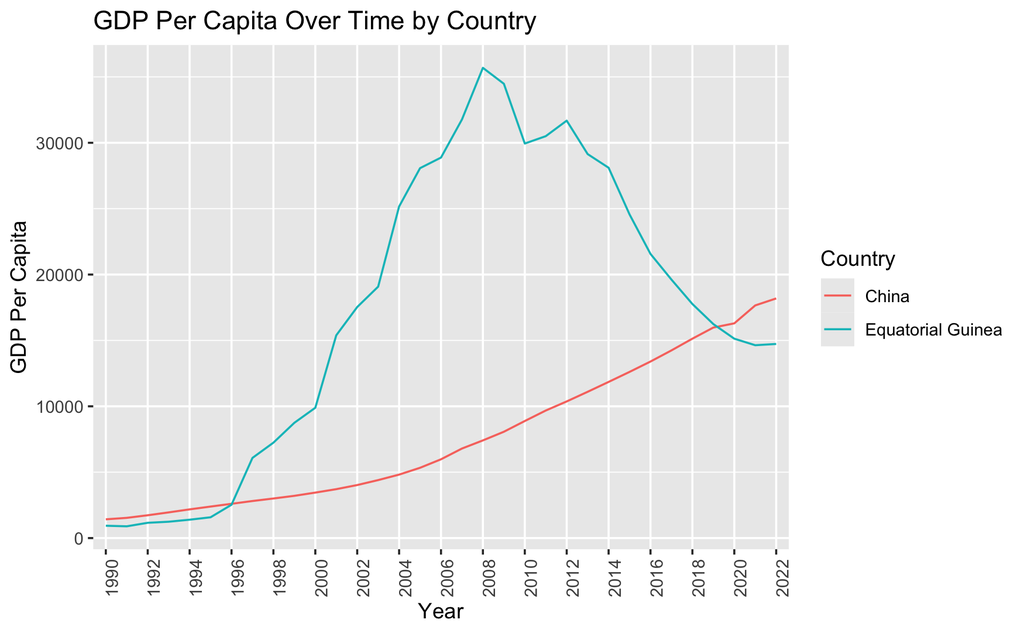

```r
# Create plot with group=Country to include both lines on same grid
ggplot(max_pct_chg, aes(x = Year, y = GDP_Per_Capita, color = Country, group=Country)) +
  geom_line() +
  labs(title = "GDP Per Capita Over Time by Country",
       x = "Year",
       y = "GDP Per Capita",
       color = "Country") +
  scale_x_discrete(breaks=seq(1990, 2022, 2)) +
  theme(axis.text.x = element_text(angle = 90))
```

13. Read in continents.csv contained in the `data` folder into a new tibble called `continents`. We will be using this tibble to add a new column to our dataset.

```r
continents <- read_csv('../data/continents.csv', show_col_types = FALSE)
continents
```

| Continent | Country |
| --- | --- |
| Asia | Afghanistan |
| Europe | Albania |
| Africa | Algeria |
| Europe | Andorra |
| Africa | Angola |
| North America | Antigua and Barbuda |
| South America | Argentina |
| Europe | Armenia |
| North America | Aruba |
| Oceania | Australia |

[output cut: 206 more lines]

14. Merge gdp_df and continents. Keep only the countries that appear in both data frames. Save the result back to gdp_df.

```r
gdp_df <- inner_join(gdp_df, continents, by='Country')
gdp_df |>
  head(3)
```

| Country | Year | GDP_Per_Capita | Continent |
| --- | --- | --- | --- |
| Afghanistan | 2021 | 1517.016 | Asia |
| Afghanistan | 2020 | 1968.341 | Asia |
| Afghanistan | 2019 | 2079.922 | Asia |

15. Determine the number of countries per continent. Create a bar chart showing this.

```r
gdp_df |>
  distinct(Country, Continent) |>
  count(Continent)
```

| Continent | n |
| --- | --- |
| Africa | 50 |
| Asia | 41 |
| Europe | 44 |
| North America | 26 |
| Oceania | 14 |
| South America | 11 |

```r
# Use count() to find number of countries per continent
continent_counts <- gdp_df |>
  distinct(Country, Continent) |>
  count(Continent)
continent_counts
```

| Continent | n |
| --- | --- |
| Africa | 50 |
| Asia | 41 |
| Europe | 44 |
| North America | 26 |
| Oceania | 14 |
| South America | 11 |

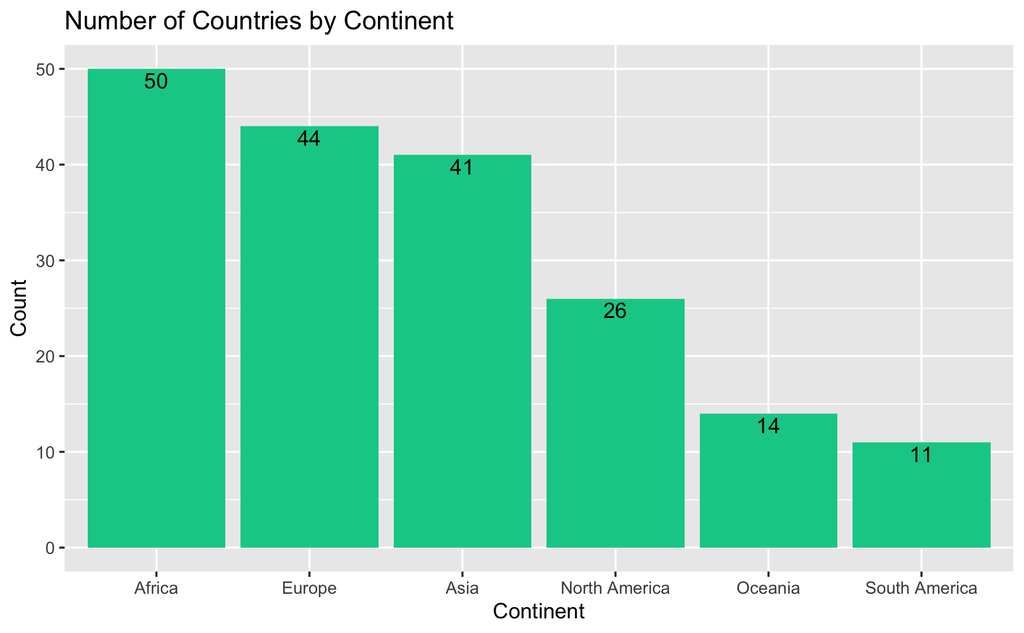

```r
# Create barplot using geom_col() to show number of countries by continent
ggplot(continent_counts, aes(x=fct_rev(fct_reorder(Continent, n)), y=n)) +
  geom_col(fill='#00CC96') +
  labs(title = "Number of Countries by Continent",
       x = "Continent",
       y = "Count")+
  geom_text(aes(label = n), vjust = 1.25)
```

16. Create a boxplot showing GDP per capita in 2021 split out by continent. What do you notice?

```r
# filter set to desired data breakdown
gdp_2021_cont <- gdp_df |>
  filter(Year==2021) |>
  group_by(Continent) |>
  summarise(GDP_Per_Capita)
gdp_2021_cont
```

| Continent | GDP_Per_Capita |
| --- | --- |
| Africa | 11029.1388 |
| Africa | 5911.8357 |
| Africa | 3321.5522 |
| Africa | 14907.0858 |
| Africa | 2179.7890 |
| Africa | 714.0667 |
| Africa | 6592.8555 |
| Africa | 3700.4643 |
| Africa | 837.5047 |
| Africa | 1425.4945 |

[output cut: 175 more lines]

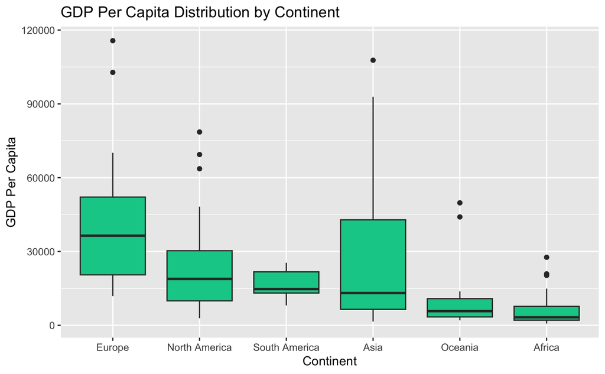

```r
# Create boxplot by continent
ggplot(gdp_2021_cont, aes(x=fct_rev(fct_reorder(Continent, GDP_Per_Capita)), y=GDP_Per_Capita)) +
  geom_boxplot(fill='#00CC96') +
  labs(title = "GDP Per Capita Distribution by Continent",
       x = "Continent",
       y = "GDP Per Capita")
```

The western world generally has a higher gdp per capita than the eastern world according to these distributions, but there are outliers that will affect the data in Asia, Oceania, and Africa.

17. Read life_expectancy.csv into a tibble named life_expectancy. Do not modify the csv file in order to read this data in.

```r
life_expectancy <- read_csv('../data/life_expectancy.csv', show_col_types = FALSE, skip = 3)
life_expectancy
```

| Country Name | Country Code | Indicator Name | Indicator Code | 1960 | 1961 | 1962 | 1963 | 1964 | 1965 | 1966 | 1967 | 1968 | 1969 | 1970 | 1971 | 1972 | 1973 | 1974 | 1975 | 1976 | 1977 | 1978 | 1979 | 1980 | 1981 | 1982 | 1983 | 1984 | 1985 | … |
| --- | --- | --- | --- | --- | --- | --- | --- | --- | --- | --- | --- | --- | --- | --- | --- | --- | --- | --- | --- | --- | --- | --- | --- | --- | --- | --- | --- | --- | --- | --- |
| Aruba | ABW | Life expectancy at birth, total (years) | SP.DYN.LE00.IN | 64.15200 | 64.53700 | 64.75200 | 65.13200 | 65.29400 | 65.50200 | 66.06300 | 66.43900 | 66.75700 | 67.16800 | 67.58300 | 67.97500 | 68.57700 | 69.09200 | 69.50300 | 69.76200 | 70.03500 | 70.26400 | 70.49400 | 70.77800 | 71.06600 | 71.72200 | 71.95900 | 72.10500 | 72.25100 | 72.38800 | … |
| Africa Eastern and Southern | AFE | Life expectancy at birth, total (years) | SP.DYN.LE00.IN | 44.08555 | 44.38670 | 44.75218 | 44.91316 | 45.47904 | 45.49834 | 45.24910 | 45.92491 | 46.22310 | 46.43230 | 46.71848 | 47.19294 | 46.89739 | 47.69232 | 47.59806 | 47.75989 | 48.34959 | 48.63591 | 48.76360 | 49.26134 | 49.63654 | 50.05707 | 50.29685 | 48.70333 | 48.65266 | 49.01163 | … |
| Afghanistan | AFG | Life expectancy at birth, total (years) | SP.DYN.LE00.IN | 32.53500 | 33.06800 | 33.54700 | 34.01600 | 34.49400 | 34.95300 | 35.45300 | 35.92400 | 36.41800 | 36.91000 | 37.41800 | 37.92300 | 38.44400 | 39.00300 | 39.55000 | 40.10000 | 40.64500 | 41.22800 | 40.27100 | 39.08600 | 39.61800 | 40.16400 | 37.76600 | 38.18700 | 33.32900 | 33.55000 | … |
| Africa Western and Central | AFW | Life expectancy at birth, total (years) | SP.DYN.LE00.IN | 37.84515 | 38.16495 | 38.73510 | 39.06372 | 39.33536 | 39.61804 | 39.83783 | 39.47150 | 40.08568 | 40.35042 | 41.03476 | 41.55672 | 42.24979 | 42.85505 | 43.49768 | 44.20125 | 45.00316 | 45.71989 | 46.26954 | 46.67374 | 47.01524 | 47.29719 | 47.52938 | 47.78526 | 47.93192 | 48.02168 | … |
| Angola | AGO | Life expectancy at birth, total (years) | SP.DYN.LE00.IN | 38.21100 | 37.26700 | 37.53900 | 37.82400 | 38.13100 | 38.49500 | 38.75700 | 39.09200 | 39.48400 | 39.82900 | 40.19000 | 40.55400 | 40.90500 | 41.27000 | 41.65200 | 41.19100 | 41.16300 | 41.43700 | 41.83000 | 42.17500 | 42.44900 | 42.77200 | 43.05100 | 42.09200 | 42.35300 | 42.64800 | … |
| Albania | ALB | Life expectancy at birth, total (years) | SP.DYN.LE00.IN | 54.43900 | 55.63400 | 56.67100 | 57.84400 | 58.98300 | 60.01900 | 60.99800 | 61.97200 | 62.94600 | 63.92300 | 64.82400 | 65.61800 | 66.42200 | 67.14000 | 67.76900 | 68.32800 | 68.70400 | 69.12100 | 69.30900 | 69.58400 | 70.47800 | 70.73000 | 71.02300 | 71.29600 | 71.50200 | 71.65600 | … |
| Andorra | AND | Life expectancy at birth, total (years) | SP.DYN.LE00.IN | NA | NA | NA | NA | NA | NA | NA | NA | NA | NA | NA | NA | NA | NA | NA | NA | NA | NA | NA | NA | NA | NA | NA | NA | NA | NA | … |
| Arab World | ARB | Life expectancy at birth, total (years) | SP.DYN.LE00.IN | 44.97290 | 45.67640 | 46.12258 | 46.97247 | 47.89576 | 48.23211 | 48.45707 | 48.91291 | 49.44512 | 49.82224 | 50.35134 | 51.29642 | 51.86446 | 52.53968 | 53.19444 | 53.70986 | 54.04753 | 55.36147 | 56.11217 | 56.82629 | 57.30237 | 57.69293 | 58.05480 | 58.78737 | 59.47898 | 60.21574 | … |
| United Arab Emirates | ARE | Life expectancy at birth, total (years) | SP.DYN.LE00.IN | 48.81100 | 49.69500 | 50.68600 | 51.58400 | 52.84800 | 53.98500 | 55.18500 | 56.33900 | 57.54000 | 58.76000 | 60.02100 | 61.21100 | 62.30400 | 63.35100 | 64.33800 | 65.08000 | 65.82000 | 66.51400 | 67.20900 | 67.84600 | 68.53000 | 69.08500 | 69.66000 | 69.94900 | 70.48500 | 70.74700 | … |
| Argentina | ARG | Life expectancy at birth, total (years) | SP.DYN.LE00.IN | 63.97800 | 64.36000 | 64.24400 | 64.44900 | 64.36300 | 64.59300 | 64.89100 | 64.99200 | 64.89000 | 64.85900 | 65.58900 | 65.54100 | 65.92300 | 66.32300 | 66.56300 | 67.08100 | 67.22800 | 67.86100 | 68.19700 | 68.49100 | 68.56400 | 68.97600 | 68.93700 | 69.26700 | 69.19500 | 69.65100 | … |

[output cut: 256 more lines]

18. Drop the Country Code, Indicator Name, and Indicator Code columns. Then use `pivot_longer` to convert your data from wide to long. That is, instead of having one row per country and multiple colums per year, we want to have multiple rows per country and a single column for year. After melting, rename the columns to `Country`, `Year`, and `Life_Expectancy`.

```r
life_expectancy <- life_expectancy |>
  select(-`Country Code`, -`Indicator Name`, -`Indicator Code`) |>
  pivot_longer(cols = -`Country Name`,
               names_to = 'Year',
               values_to = 'Life_Expectancy') |>
  rename(Country = `Country Name`) |>
  mutate(Year = as.double(Year))
life_expectancy
```

| Country | Year | Life_Expectancy |
| --- | --- | --- |
| Aruba | 1960 | 64.15200 |
| Aruba | 1961 | 64.53700 |
| Aruba | 1962 | 64.75200 |
| Aruba | 1963 | 65.13200 |
| Aruba | 1964 | 65.29400 |
| Aruba | 1965 | 65.50200 |
| Aruba | 1966 | 66.06300 |
| Aruba | 1967 | 66.43900 |
| Aruba | 1968 | 66.75700 |
| Aruba | 1969 | 67.16800 |

[output cut: 990 more lines]

19. What was the first country with a life expectancy to exceed 80?

```r
life_expectancy |>
  filter(Life_Expectancy>=80) |>
  arrange(Year) |>
  head(1)
```

| Country | Year | Life_Expectancy |
| --- | --- | --- |
| Japan | 1996 | 80.21976 |

20. Merge `gdp_df` and `life_expectancy`, keeping all countries and years that appear in both tibbles. Save the result to a new tibble named `gdp_le`. If you get any errors in doing this, read them carefully and correct them. Look at the first five rows of your new data frame to confirm it merged correctly. Also, check the last five rows to make sure the data is clean and as expected.

```r
gdp_le <- inner_join(gdp_df, life_expectancy, by=c('Country' , 'Year'))
gdp_le |>
  head()
```

| Country | Year | GDP_Per_Capita | Continent | Life_Expectancy |
| --- | --- | --- | --- | --- |
| Afghanistan | 2021 | 1517.016 | Asia | 61.982 |
| Afghanistan | 2020 | 1968.341 | Asia | 62.575 |
| Afghanistan | 2019 | 2079.922 | Asia | 63.565 |
| Afghanistan | 2018 | 2060.699 | Asia | 63.081 |
| Afghanistan | 2017 | 2096.093 | Asia | 63.016 |
| Afghanistan | 2016 | 2101.422 | Asia | 63.136 |

```r
gdp_le |>
  tail()
```

| Country | Year | GDP_Per_Capita | Continent | Life_Expectancy |
| --- | --- | --- | --- | --- |
| Zimbabwe | 1995 | 2641.378 | Africa | 50.531 |
| Zimbabwe | 1994 | 2670.107 | Africa | 52.588 |
| Zimbabwe | 1993 | 2458.783 | Africa | 54.426 |
| Zimbabwe | 1992 | 2468.278 | Africa | 56.435 |
| Zimbabwe | 1991 | 2781.788 | Africa | 58.091 |
| Zimbabwe | 1990 | 2704.757 | Africa | 59.426 |

21. Create a new tibble, named `gdp_le_2021` by extracting data for the year 2021 from `gdp_le`. How many countries have a life expectancy of at least 80 in 2021?

```r
gdp_le_2021 <- gdp_le |>
  filter(Year==2021)
gdp_le_2021 |>
  filter(Life_Expectancy >=80) |>
  count()
```

| n |
| --- |
| 31 |

22. Find the countries that had the top 3 largest GDP per capita figures for 2021. Create a plot showing the change in life expectancy over time for these three countries. This plot should be faceted so that each country is contained in its own figure.

```r
# Filter the top three countries by GDP Per Capita
top_three_gdppc <- gdp_le_2021 |>
  arrange(desc(GDP_Per_Capita)) |>
  head(3) |>
  pull(Country)
```